# Applied Statistics Modelling Coursework MATH3046

Student ID: 20308995

2023-04-11

## Executive Summary | Respiratory Disease Data Analysis

This report investigates factors associated with the risk of respiratory diseases in infants and build a risk prediction model to estimate the probability of an infant developing respiratory disease.

## Introduction

1. status (status respiratory disease) Metric: 0 (No), 1 (Yes)
2. gender Metric: F (Female), M (Male)
3. fed_method: feeding methods Metric: 4 categories (breastfeed only, bottle feed only, mix bottle and breast feed, supplement only)
4. sleep_hour: average number of sleeping hours
5. delivery_type: type of delivery Metric: 0 (Natural Birth), 1 (Cesarean birth)
6. weight: weight of mother before pregnancy Metric: 0 (Underweight), 1 (Normal Weight)
7. smoking: smoking status of mother before pregnancy Metric: N (No), Y (Yes)
8. diabetes: mother with gestational diabetes Metric: N (No). Y (Yes)
9. API: air pollution index Metric: 0-50: good, 51-100: moderate, 101-200: unhealthy, 201-300: very unhealthy, >300: hazardous

Additionally, we have checked that the data set contains no missing data. Therefore, we can proceed to exploratory analyses.

```
## spc_tbl_ [18,422 × 9] (S3: spec_tbl_df/tbl_df/tbl/data.frame)
##  $ status       : num [1:18422] 0 1 0 0 1 1 1 0 0 0 ...
##  $ gender       : chr [1:18422] "M" "F" "F" "F" ...
##  $ fed_method   : chr [1:18422] "Supplement" "Supplement" "Supplement" "Supplement" ...
##  $ sleep_hour   : num [1:18422] 11.6 12.5 12.5 12.5 12.5 ...
##  $ API          : chr [1:18422] "101-200" "201-300" "201-300" "201-300" ...
##  $ diabetes     : chr [1:18422] "Y" "Y" "Y" "Y" ...
##  $ delivery_type: num [1:18422] 0 1 1 1 1 0 0 0 0 0 ...
##  $ smoking      : chr [1:18422] "N" "N" "N" "N" ...
##  $ weight       : num [1:18422] 1 1 1 0 0 1 1 1 1 1 ...
##  - attr(*, "spec")=
##   .. cols(
##   ..   status = col_double(),
##   ..   gender = col_character(),
##   ..   fed_method = col_character(),
##   ..   sleep_hour = col_double(),
##   ..   API = col_character(),
##   ..   diabetes = col_character(),
##   ..   delivery_type = col_double(),
##   ..   smoking = col_character(),
##   ..   weight = col_double()
##   .. )
##  - attr(*, "problems")=<externalptr>
```

```
## [1] "Number of Missing Data: 0"
```

## Exploratory Analyses

The output observed below shows the frequency or the proportion of infants split by their `status` on whether they have respiratory disease or not.

| status | gender | n | freq |
| --- | --- | --- | --- |
| 0 | F | 7664 | 62.25327 |
| 0 | M | 4647 | 37.74673 |
| 1 | F | 3810 | 62.34659 |
| 1 | M | 2301 | 37.65341 |

| status | delivery_type | n | freq |
| --- | --- | --- | --- |
| 0 | 0 | 11084 | 90.033304 |
| 0 | 1 | 1227 | 9.966696 |
| 1 | 0 | 5417 | 88.643430 |
| 1 | 1 | 694 | 11.356570 |

| status | weight | n | freq |
| --- | --- | --- | --- |
| 0 | 0 | 2383 | 19.35667 |
| 0 | 1 | 9928 | 80.64333 |
| 1 | 0 | 1265 | 20.70038 |
| 1 | 1 | 4846 | 79.29962 |

| status | smoking | n | freq |
| --- | --- | --- | --- |
| 0 | N | 12311 | 100 |
| 1 | N | 6111 | 100 |

| status | diabetes | n | freq |
| --- | --- | --- | --- |
| 0 | N | 4345 | 35.29364 |
| 0 | Y | 7966 | 64.70636 |
| 1 | N | 2009 | 32.87514 |
| 1 | Y | 4102 | 67.12486 |

| status | API | n | freq |
| --- | --- | --- | --- |
| 0 | 0-50 | 1092 | 8.870116 |
| 0 | 101-200 | 8566 | 69.580050 |
| 0 | 201-300 | 1653 | 13.427016 |
| 0 | 51-100 | 715 | 5.807814 |
| 0 | >300 | 285 | 2.315003 |
| 1 | 0-50 | 469 | 7.674685 |
| 1 | 101-200 | 4273 | 69.923090 |
| 1 | 201-300 | 879 | 14.383898 |
| 1 | 51-100 | 337 | 5.514646 |
| 1 | >300 | 153 | 2.503682 |

[output not shown]

| status | mean(sleep_hour) |
| --- | --- |
| 0 | 12.05771 |
| 1 | 12.07157 |

| status | fed_method | n | freq |
| --- | --- | --- | --- |
| 0 | Bottle feed only | 488 | 3.9639347 |
| 0 | Mix bottle and breastfeed | 104 | 0.8447730 |
| 0 | Supplement | 8260 | 67.0944684 |
| 0 | breastfeed only | 3459 | 28.0968240 |
| 1 | Bottle feed only | 251 | 4.1073474 |
| 1 | Mix bottle and breastfeed | 42 | 0.6872852 |
| 1 | Supplement | 4156 | 68.0085092 |
| 1 | breastfeed only | 1662 | 27.1968581 |

The descriptive tables above generates several findings:

- There are 12,311 infants (female: 7664, male: 4647) who do not have respiratory disease and 6111 infants who have the respiratory disease (female: 3810, male: 2301).
- Large proportion of infants from both `status` are delivered through natural birth (90% of infants who do not have respiratory disease and 88.6% of infants who do have respiratory disease).
- All mothers with infants from both `status` did not smoke prior to pregnancy. Therefore this variable will not be useful for our data analysis as we cannot determine if smoking affects the probability of infants developing respiratory disease or not.
- Large proportion of infants from both `status` are categorized to have normal weight (80.6% of infants who do not have respiratory disease have normal weight and 79% of infants who do have respiratory disease have normal weight).
- Large proportion infants from both status live in areas with air pollution index `API` of 101-200
- Average sleep of infants from both status is 12.05
- Large proportion of infants from both `status` have gestational diabetes (67.1% of infants who do have respiratory disease and 64.7% of infants who do not have respiratory disease have mothers with gestational diabetes).
- Large proportion of infants from both `status` are fed by supplements (67% infants who do not respiratory disease 68% infants who have respiratory disease are fed using supplements)

In summary, we can dismiss ‘smoking’ as an important variable to consider as all infants within this data set have mothers who did not smoke prior to their pregnancy. The remaining variables will need to be deeply more investigated as the remaining factors above has not shown any conclusive evidence of whether it has any impact on infants developing respiratory disease.

Next, we will starting by ensuring that all categorical variables are written as factor levels as shown below:

```
##   F
## M 0
## F 1
```

```
##                           Bottle feed only Mix bottle and breastfeed Supplement
## breastfeed only                          0                         0          0
## Bottle feed only                         1                         0          0
## Mix bottle and breastfeed                0                         1          0
## Supplement                               0                         0          1
```

```
##         >300 101-200 201-300 51-100
## 0-50       0       0       0      0
## >300       1       0       0      0
## 101-200    0       1       0      0
## 201-300    0       0       1      0
## 51-100     0       0       0      1
```

```
##   Y
## N 0
## Y 1
```

```
##   Y
## N 0
## Y 1
```

```
##   1
## 0 0
## 1 1
```

```
##   1
## 0 0
## 1 1
```

Chi-squared test will be used to assess whether there is difference between respiratory status for each of the factors (excluding `smoking`) in the *Training.csv* data set. The factors that will be analysed includes: `API`, `weight`, `gender`, `fed_method`, `delivery_type`,and `diabetes`.

Prior to using chi-squared distribution, several assumptions need to be fulfilled:

1. All observations are independent: this assumption is fulfilled as each infant’s respiratory status does not affect another infant’s respiratory status.
2. The levels of the categorical variables are mutually exclusive: As seen within the *Training.csv* data set, each infant fits to only one level of each of the categorical variables.

### Chi-Square test to determine difference between status of respiratory for each variables of Interest:

$H_0$: infant’s gender and respiratory status are independent

$H_1$: infant’s gender and respiratory status are dependent

```r
#gender
cont_table0 <- table(training$status,training$gender)
chisq.test(cont_table0)
```

```
##
##  Pearson's Chi-squared test with Yates' continuity correction
##
## data:  cont_table0
## X-squared = 0.011427, df = 1, p-value = 0.9149
```

$H_0$: infant’s weight and respiratory status are independent

$H_1$: infant’s weight and respiratory status are dependent

```r
#weight
cont_table1 <- table(training$status,training$weight)
chisq.test(cont_table1)
```

```
##
##  Pearson's Chi-squared test with Yates' continuity correction
##
## data:  cont_table1
## X-squared = 4.5588, df = 1, p-value = 0.03275
```

$H_0$: infant’s API and respiratory status are independent

$H_1$: infant’s API and respiratory status are dependent

```r
#API
cont_table2 <-table(training$status,training$API)
chisq.test(cont_table2)
```

```
##
##  Pearson's Chi-squared test
##
## data:  cont_table2
## X-squared = 10.903, df = 4, p-value = 0.02768
```

$H_0$: infant’s diabetes and respiratory status are independent

$H_1$: infant’s diabetes and respiratory status are dependent

```r
#diabetes
cont_table3<-table(training$status,training$diabetes)
chisq.test(cont_table3)
```

```
##
##  Pearson's Chi-squared test with Yates' continuity correction
##
## data:  cont_table3
## X-squared = 10.465, df = 1, p-value = 0.001217
```

$H_0$: infant’s fed_method and respiratory status are independent

$H_1$: infant’s fed_method and respiratory status are dependent

```r
#fed_method
cont_table6 <- table(training$status,training$fed_method)
chisq.test(cont_table6)
```

```
##
##  Pearson's Chi-squared test
##
## data:  cont_table6
## X-squared = 3.1835, df = 3, p-value = 0.3642
```

$H_0$: infant’s delivery_type and respiratory status are independent

$H_1$: infant’s delivery_type and respiratory status are dependent

```r
#delivery_type
cont_table7 <- table(training$status,training$delivery_type)
chisq.test(cont_table7)
```

```
##
##  Pearson's Chi-squared test with Yates' continuity correction
##
## data:  cont_table7
## X-squared = 8.2979, df = 1, p-value = 0.003969
```

Additionally, for `sleep_hour` we have to conduct a t-test as it is a continuous variable. Prior to doing t-test, we must check for normality assumptions.

1. All observations are independent: this assumption is fulfilled as each infant’s respiratory status is not affected by another infant’s
2. Normality: we will check this assumption by drawing up the QQ-plot

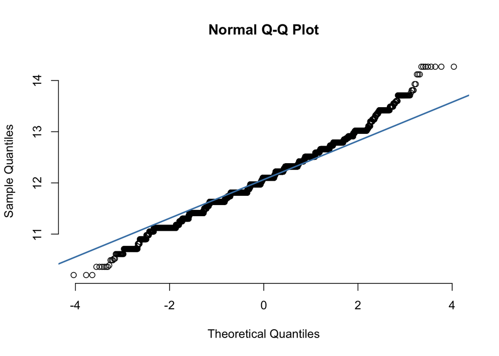

```r
qqnorm(training$sleep_hour, pch = 1, frame = FALSE)
qqline(training$sleep_hour,col = "steelblue", lwd = 2)
```

Based on the QQ plot, we can safely assume that `sleep_hour` is normally distributed as most of the data points fall approximately to the reference line. We may proceed to using the t-test to determine if there are any difference between `sleep_hour` and `status`.

**T-test Between `Status` and `Sleep_Hour`**

$H_0$: $\mu_A= \mu_B$ $H_1$: $\mu_A\neq \mu_B$

where $A$ represents `sleep_hour` with `status` = 0 (infant does not have respiratory disease) and $B$ represents `sleep_hour` with `status`=1 (infant has respiratory disease)

```r
#sleep_hour T-Test

respiratory_status_0 <- subset(training, status == 0)
respiratory_status_1 <- subset(training, status == 1)

# Conduct a two-sample t-test

t.test(respiratory_status_0$sleep_hour, respiratory_status_1$sleep_hour)
```

```
##
##  Welch Two Sample t-test
##
## data:  respiratory_status_0$sleep_hour and respiratory_status_1$sleep_hour
## t = -1.89, df = 11944, p-value = 0.05878
## alternative hypothesis: true difference in means is not equal to 0
## 95 percent confidence interval:
##  -0.028232536  0.000514313
## sample estimates:
## mean of x mean of y
##  12.05771  12.07157
```

Based on the t-test output, the p-value shown is 0.05878 which is greater than the 5% significance level. Therefore `sleep_hour` does not show any difference based on the infant’s different `status` . Additionally, the 95% confidence interval from the `t.test()` command reflects the same result as with looking at the p-value.

# Assumption of Generalised Linear Model

## Checking linear assumption in the case of logistic regression

To satisfy the linear assumption for logistic regression, we need to check the linear relationship visually between the continuous predictor variable *sleep_hour* and the logit of the infant’s *status*.

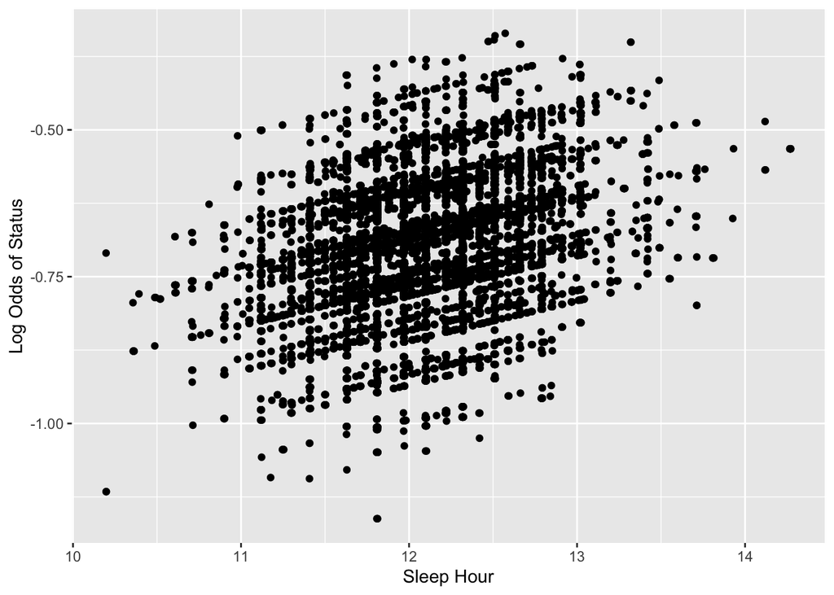

```r
# fit logistic regression model
model <- glm(status~gender+fed_method+sleep_hour+API+diabetes+delivery_type+weight, data = training,
               family = binomial)

ggplot(training, aes(x = sleep_hour, y = log(model$fitted.values / (1 - model$fitted.values)))) +
  geom_jitter() +
  xlab("Sleep Hour") +
  ylab("Log Odds of Status")
```

Based on the scatter plot above, *sleep_hour* is linearly associated with infant’s log odds *status*. Therefore, we may proceed to model selection as linearity assumption for logistic regression is satisfied.

## Model Fitting

For the subsequent model fitting, we will categorize the average sleeping hour into 3 groups: <11.6 hours, 11.6-12.9 hours, and >12.9 hours.

```r
training$sleep_hour <- cut(training$sleep_hour, breaks = c(-Inf, 11.6, 12.9, Inf),
                  labels = c("<11.6 hours", ">11.6-12.9 hours", ">12.9 hours"),
                  right = FALSE, include.lowest = TRUE)
```

We are now ready to start model fitting to the data set. We will use step wise regression through forward selection method to determine which variables are important in developing a prediction model to determine an infant’s respiratory status

```r
fit0 <- glm(status~1,data=training,family=binomial(link=logit))
fit_step2 <-step(fit0,scope=status~gender+fed_method+sleep_hour+API+diabetes+delivery_type+weight)
```

```
## Start:  AIC=23412.39
## status ~ 1
##
##                 Df Deviance   AIC
## + diabetes       1    23400 23404
## + delivery_type  1    23402 23406
## + sleep_hour     2    23400 23406
## + API            4    23399 23409
## + weight         1    23406 23410
## <none>                23410 23412
## + gender         1    23410 23414
## + fed_method     3    23407 23415
##
## Step:  AIC=23403.77
## status ~ diabetes
##
##                 Df Deviance   AIC
## + sleep_hour     2    23390 23398
## + delivery_type  1    23393 23399
## + API            4    23389 23401
## + weight         1    23395 23401
## <none>                23400 23404
## + gender         1    23400 23406
## + fed_method     3    23396 23406
## - diabetes       1    23410 23412
##
## Step:  AIC=23398.27
## status ~ diabetes + sleep_hour
##
##                 Df Deviance   AIC
## + delivery_type  1    23384 23394
## + weight         1    23386 23396
## + API            4    23380 23396
## <none>                23390 23398
## + fed_method     3    23385 23399
## + gender         1    23390 23400
## - sleep_hour     2    23400 23404
## - diabetes       1    23400 23406
##
## Step:  AIC=23394.25
```

[output cut: 36 more lines]

```
## - diabetes       1    23378 23396
##
## Step:  AIC=23389.1
## status ~ diabetes + sleep_hour + delivery_type + API + weight +
##     fed_method
##
##                 Df Deviance   AIC
## <none>                23363 23389
## - fed_method     3    23369 23389
## + gender         1    23363 23391
## - weight         1    23368 23392
## - API            4    23374 23392
## - sleep_hour     2    23373 23395
## - delivery_type  1    23371 23395
## - diabetes       1    23372 23396
```

## Final Model

Based on the outputs above, we have concluded a final prediction model to estimate the probability of an infant developing respiratory disease.

```r
out7<-glm(formula=status~diabetes+sleep_hour+delivery_type+API+weight+fed_method,data=training,family=binomial(link=logit))
summary(out7)
```

```
##
## Call:
## glm(formula = status ~ diabetes + sleep_hour + delivery_type +
##     API + weight + fed_method, family = binomial(link = logit),
##     data = training)
##
## Deviance Residuals:
##     Min       1Q   Median       3Q      Max
## -1.0727  -0.9103  -0.8749   1.4495   1.6806
##
## Coefficients:
##                                     Estimate Std. Error z value Pr(>|z|)
## (Intercept)                         -1.00343    0.08519 -11.779  < 2e-16 ***
## diabetesY                            0.09622    0.03328   2.892  0.00383 **
## sleep_hour>11.6-12.9 hours           0.09440    0.04846   1.948  0.05139 .
## sleep_hour>12.9 hours                0.28552    0.09341   3.057  0.00224 **
## delivery_type1                       0.14286    0.05095   2.804  0.00504 **
## API>300                              0.22689    0.11466   1.979  0.04783 *
## API101-200                           0.14807    0.05846   2.533  0.01132 *
## API201-300                           0.20934    0.06941   3.016  0.00256 **
## API51-100                            0.09929    0.08628   1.151  0.24980
## weight1                             -0.08156    0.03901  -2.091  0.03656 *
## fed_methodBottle feed only           0.09047    0.08367   1.081  0.27958
## fed_methodMix bottle and breastfeed -0.14234    0.18574  -0.766  0.44348
## fed_methodSupplement                 0.07946    0.03620   2.195  0.02816 *
## ---
## Signif. codes:  0 '***' 0.001 '**' 0.01 '*' 0.05 '.' 0.1 ' ' 1
##
## (Dispersion parameter for binomial family taken to be 1)
##
##     Null deviance: 23410  on 18421  degrees of freedom
## Residual deviance: 23363  on 18409  degrees of freedom
## AIC: 23389
##
## Number of Fisher Scoring iterations: 4
```

Based on the R output above, `status ~ diabetes + sleep_hour + delivery_type + API + weight + fed_method` is the best model as it has the lowest AIC value of $23389.1$.

*Final Prediction Model*:

$log(\frac{p}{1-p}) = -1+0.096a_i+0.094b_{i1}+0.29b_{i2}+0.14c_i + 0.099d_{i1}+0.15d_{i2} +0.21d_{i3} + 0.23d_{i4} - 0.08e_{i} + 0.09f_{i1} - 0.14f_{i2} + 0.08f_{i3}$

where:

- $a_i$ = 1 if `diabetes` = Yes, else 0
- $b_{i1}$ = 1 if `sleep_hour` is 11.6-12.9 hours,else 0
- $b_{i2}$ =1 if `sleep_hour` >12.9 hours, else 0
- $c_i$ =1 if `delivery_type` is cesarean, else 0
- $d_{i1}$ = 1 if `API` 51-100, else 0
- $d_{i2}$ = 1 if `API` 101-200, else 0
- $d_{i3}$ = 1 if `API` 201-300, else 0
- $d_{i4}$ = 1 if `API` >300, else 0
- $e_i$ = 1 if `weight` is normal, else 0
- $f_{i1}$= 1 if `fed_method` is bottle feed only, else 0
- $f_{i2}$ = 1 if `fed_method` is mix bottle, else 0
- $f_{i3}$ = 1 if `fed_method` is supplement only, else 0

[figure not shown]

Results Table

**P-value**

Based on the p-value output in the output above, we observe that `diabetes`,`sleep_hour>12.9`, `delivery_type1`,`API>300`,`API101-200`,`API201-300`,`weight`,`fed_methodSupplement` are smaller than the 5% significance level. Therefore we can conlude that these variables are important variables to consider in predicting an infant’s respiratory `status`.

**95% Confidence Interval Based on the Odds Ratio**:

**Odds Ratio of Final Model**:

Based on the odds ratio above,

1. The odds of an infant developing respiratory disease with normal weight mothers is (1-0.9216815=0.078) 7.8% lower compared to infants with underweight mothers.
2. The odds of an infant developing respiratory disease is (1.1535730) 15% higher for infants delivered by cesarean section than normal birth.
3. The odds of an infant developing respiratory disease is (1.1010036) 10.1% higher for infants who have mothers with gestational diabetes compared to mothers who do not have gestational diabetes.
4. The odds of an infant developing respiratory disease is (1.2546963) 25.4% higher for infants living in air pollution index of >300, and (1.1595934) 15.9% higher for infants living in air pollution index of 101-200, (1.2328598) 23.2% higher for infants living in air pollution index of 201-300, (1.1043857) 10.4% higher for infants living in air pollution index of 51-100 compared to infants living in air pollution index below 50.
5. The odds of an infant developing respiratory disease is (1-0.8673263=0.1326) 13.26% times lower for infants being fed with mix of bottle and breastfeed, (1.0946860) 9.46% higher for infants with bottle feed only, (1.0827051) 8.27% higher for infants fed with supplement only compared to infants who breastfeed only.
6. The odds of an infant developing respiratory disease is 33% higher for infants sleeping greater than 12.9 hours and the odds of an infant developing respiratory disease is 9.9% higher for infants sleeping between 11.6-12.9 hours compared to infants who slept less than 11.6 hours.

## Testing Model Accuracy

To test the accuracy of the model, we will use our final prediction model onto the `Testing.csv` data set and compare the predicted outcomes with the actual outcomes.

```r
test_data <- read_csv("/Users/aliciaclara/Documents/R files/Applied_dataset/MATH3046_test_data.csv",show_col_types=FALSE)

head(test_data)
```

| status | gender | fed_method | sleep_hour | API | diabetes | delivery_type | smoking | weight |
| --- | --- | --- | --- | --- | --- | --- | --- | --- |
| 0 | F | breastfeed only | 11.30 | >300 | Y | 0 | N | 1 |
| 0 | M | Supplement | 11.67 | 201-300 | N | 0 | N | 1 |
| 1 | M | Bottle feed only | 12.02 | 201-300 | N | 0 | N | 1 |
| 1 | F | Supplement | 11.59 | 101-200 | N | 0 | N | 1 |
| 0 | F | Supplement | 11.30 | 101-200 | Y | 0 | N | 1 |
| 0 | F | breastfeed only | 11.71 | 101-200 | N | 0 | N | 0 |

```r
#calculate number of rows
nrow(test_data)
```

```
## [1] 500
```

```r
set.seed(100)

test_subset <- test_data[, c("sleep_hour","weight", "delivery_type", "diabetes", "API","fed_method")]


predict_result <- predict(out7,test_subset,type="response")
predict_result <- ifelse(predict_result>=0.5,"1","0")
table(test_data$status, predict_result)
```

```
##    predict_result
##       0
##   0 333
##   1 167
```

The contingency table output above shows that the model correctly classifying 333 infants not having respiratory disease. However, 167 infants were categorised incorrectly by the prediction model as the model interprets the infants having no respiratory disease contrary to the actual outcome.

# Summary

In this report, we have investigated which factors are significant based on the infant’s `status` and built a prediction model to estimate the risk of an infant developing respiratory disease. Based on our prediction model, we have concluded that `fed_method`, `diabetes`, `sleep_hour`, `delivery_type`, `API`,and `weight` are important variables to consider in investigating whether an infant is likely to develop respiratory disease.

We have found no evidence that suggest that `gender` plays a significant role in determining whether an infant is likely to develop respiratory disease based on the chi-square test and during the model development. Additionally, `smoking` variable plays no role in the model development as all mothers in this data set did not smoke prior to their pregnancy. Below are all the main findings of each of the important variables:

## Detailed Summary of the Important Factors Impacting the Odds of Infants Developing Respiratory Disease

**Respiratory Status and Delivery_Type**: Our findings show that large proportion of infants from both respiratory status are delivered by natural birth which was shown in the exploratory analyses table. We investigated `delivery_type` using chi-square test which indicated there exist differences between `status` of infant and `delivery_type`. Based on the prediction model, we found that infants delivered by cesarean section to be statistically significant at the 5% significance level and infants who are delivered by cesarean section have higher risk in developing respiratory disease by 15% compared to infants from normal birth. Therefore, `delivery_type` has a great impact on whether an infant develops respiratory disease.

**Respiratory Status and Diabetes** : Our findings show a large proportion of infants from both respiratory `status` have mothers with gestational diabetes. We investigated the significance of `diabetes` using the chi-square tests and have found that there exists difference between infant’s `status` and `diabetes`. Based on the prediction model , we discovered that infants who have mothers with gestational diabetes are at risk of developing respiratory disease by 10.1% higher compared to infants who do not have mothers with gestational diabetes

**Respiratory Status and Weight**: Our exploratory analysis have shown that large proportion of infants from both respiratory `status` have normal weight (`weight`=1). Based on the chi-square test, we discovered that there is difference between infant’s `status` and `weight`. The prediction model shows that `weight` is an important variable to consider as it is statistically significant at the 5% level. The odds of an infant developing respiratory disease is 7.86% lower for normal weight mothers compared to underweight mothers

**Respiratory Status and API**: Our exploratory analysis show that most infants from both respiratory `status` live in air pollution index (`API`) between 101-200. Based on the chi-square tset, we discovered that there exist difference between infant’s `status` and `API`. The model development also shows that `API` is an important variable to consider specifically, for `API`>300, `API`: 101-200, and `API`: 201-300 at the 5% significance level. The odds of an infant developing respiratory disease is 25.5% higher for infants living in API of >300 compared to infants living in API < 50. The odds of an infant developing respiratory disease is 16% higher for infants living in air pollution index of 101-200 and 23.3% higher for infants living in API 201-300 compared to infants living in API < 50.

**Limitation of Analysis**

Inclusion of other factor variables such as premature birth, inclusion of maternal smoking and genetic factors could help in improving the model prediction and increase the model accuracy. Currently, the model prediction accurately predicts 66.67% of known infant’s respiratory `status` on the `Testing` data set. This level of accuracy is insufficient as using this current risk prediction model could cause large number of infants to not receive preventive interventions.

**Probability of an infant developing respiratory disease within their first month after birth:**

The fitted model explained above would not be appropriate to determine the probability of an infant developing respiratory disease within their first month after birth. A suitable model to answer this question would be to use survival analysis. Data collection of censored infants (e.g. left censoring: infants who have developed the respiratory disease before trial, right censoring: infant has not developed respiratory disease by the time of trial) needs to be collected. Specifically, a cox model would be appropriate to use in identifying the probability of an infant developing respiratory disease within their first month after birth.